# Análisis del rendimiento de los equipos de fútbol en tiempos de pandemia

El caso de la Súperliga de Grecia

Juan David López

Jose Guerrero

# Introducción

El 11 de marzo de 2020, la Organización Mundial de la Salud declaró una pandemia. Rápidamente se fue paralizando el mundo. A esa fecha se habían confirmado 117.573.007 casos y registrado [2.610.925 muertes](https://www.frontiersin.org/articles/10.3389/fspor.2021.695922/full#B36). Los países afectados se vieron en la necesidad de implementar diferentes tipos de restricción que impactaron la manera en que estábamos acostumbrados a movilizarnos, más allá del impacto en salubridad por el COVID-19. En vista de las masas que mueve el deporte, entre otros espectáculos, este tipo de eventos se debió suspender. Entre otros, los Juegos Olímpicos y Paralímpicos de Tokio fueron aplazados. Gracias a la evolución en los tratamientos y a la aplicación de estrictos protocolos sanitarios, algunos campeonatos profesionales se reanudaron con algunas restricciones, por ejempo, limitados a realizarse a puerta cerrada en estadios vacíos. Bajo estas nuevas circunstancias, surge la inquietud al respecto de **cómo esta situación extraordinaria afectó el rendimiento de los equipos de fútbol**, en vista de la supuesta ventaja que ofrecían los juegos de local al contar con la mayoría de espectadores alentando. Según estudios <sup>1</sup> basados en datos históricos, los equipos locales ganan de manera consistente más del 50% de los partidos jugados sobre un calendario equilibrado en juegos de local y visitante.

Nuestra firma, siempre interesada en producir valiosos insights para nuestros clientes y en atención a su solicitud al respecto, dedicó a uno de sus equipos de analítica a estudiar esta incógnita enfocado particularmente en dicho efecto sobre los equipos de la Súperliga de fútbol de Grecia.

Los datos sobre los cuales está sustentado este análisis provienen de nuestra propia recolección y, Si bien nos ocuparemos en un trabajo futuro de revisar un modelo estadístico para medir el efecto de jugar a puerta cerrada durante situación de pandemia, sobre la ventaja de jugar de local, **en esta etapa cubrimos lo concerniente al análisis exploratorio de los datos**.

Este informe aporta a continuación algo de contexto respecto a la súperliga de Grecia y cuenta con cuatro secciones adicionales: en la primera, presentamos detalles respecto a los datos recolectados y a su estructura de variables; en la segunda nos referimos a los hallazgos en materia de anomalías y a las transformaciones realizadas en consecuencia. La tercera sección describe las variables que adicionamos para favorecer a los trabajos futuros y la última sección contempla algunas conclusiones acerca del proceso, así como, algunas recomendaciones de interés para los equipos de recolección de datos.

/1. Ref. *Courneya, K. S., and Carron, A. V. (1992). The home advantage in sport competitions: a literature review. J. Sport Exerc. Psychol. 14, 13–27. doi: 10.1123/jsep.14.1.13*

## Superliga de Grecia

La Superliga de Grecia (en griego, Ελληνική Σούπερ Λίγκα) es una competición entre clubes de fútbol de Grecia. Es la primera división del fútbol griego.

[figure not shown]

*Fuente. Transfermarkt.es*

### Sistema de competición

La Federación Helénica de Fútbol organiza este torneo de liga y el sistema de puntuación es el siguiente: tres puntos para el vencedor de un partido, cero puntos para el perdedor de un partido y en caso de que dos equipos hayan empatado un partido, se les compensa con un punto para cada uno. La Superliga otorga dos plazas para la UEFA Champions League (campeón y subcampeón) y dos para la UEFA Europa League (tercero y cuarto), además de la del campeón de la Copa de Grecia.

Los 14 equipos participantes juegan entre sí todos contra todos a dos ruedas, totalizando 26 partidos cada uno. Al término de la fecha 26, los seis primeros clasificados disputarán la Ronda campeonato, mientras que los ocho restantes pasarán a jugar la Ronda por la permanencia. Los puntos obtenidos hasta la última fecha de la fase regular serán transferidos a la segunda fase, respectivamente a la zona en que se encuentre cada club.

### Temporadas 2018-2022

En función de aportar elementos de contexto a nuestro análisis, algunos datos de interés que hicieron parte de nuestra investigación son:

#### 2021-2022

La temporada 2021-22 es la edición número 85 de la Superliga de Grecia. La misma comenzó el 11 de septiembre de 2021 y terminará en mayo de 2022. Olympiakos es el campeón defensor.

#### 2020-2021

La temporada inició el 11 de septiembre de 2020 y finalizó el 19 mayo 2021. El campeón fue Olympiakos y Descendieron Panaitolikos y AE Larisa. LOs partidos se disputaron con público a partir del 24 de octubre de 2020 con el 10% del aforo.

#### 2019-2020

La temporada comenzó el 24 de agosto de 2019 y finalizó el 19 de julio de 2020. El campeón fue Olympiakos y Descendieron Xanthi y Panionios. Los partidos posteriores al 1 de marzo de 2020 se disputaron sin público.

### Estadios

| Equipo | Ciudad | Estadio | Capacidad |
| --- | --- | --- | --- |
| AEK Atenas | Atenas | Estadio Olímpico de Atenas | 69.618 |
| Apollon Smyrnis | Atenas | Georgios Kamaras Stadium | 14.200 |
| Aris Thess | Thessaloniki | Estadio Kleanthis Vikelidis | 22.800 |
| Asteras Trípoli | Trípoli | Estadio Theodoros Kolokotronis | 7.442 |
| Atromitos | Peristeri | Estadio Peristeri | 9.050 |
| Lamia | Lamía | Estadio Municipal de Lamia | 5.500 |
| OFI | Heraklion | Estadio Theodoros Vardinogiannis | 9.088 |
| Olympiakos | Piraeus | Estadio Georgios Karaiskakis | 32.115 |
| Panathinaikos | Atenas | Estadio Apostolos Nikolaidis | 16.620 |
| Panetolikos | Agrinio | Estadio Panetolikos | 7.321 |
| PAOK Salónica | Thessaloni | Estadio La Tumba | 28.703 |
| PAS Giannina | Ioannina | Estadio Zosimades | 7.652 |
| Volos | Volos | Estadio Panthessaliko | 22.700 |

En contexto, la capacidad de los estadios puede determinar la influencia mayor o menor que algunos equipos tienen al jugar de local, en vista por supuesto de la amplia diferencia en capacidad de espectadores que moviliza.

# Sobre los datos

## Recolección

Los datos proceden de fuente propia producto de la recolección por parte de nuestro equipo y se dispusieron en tres 3 bases de datos: Temporada 2018-2019, Temporada 2019-2020 y Temporada 2020-2021.

### Temporada 2018-1019

En esta base de datos se encuentran la información de los partidos disputados en la temporada 2018-2019 de la Superliga de Grecia, distribuida en 61 columnas y 240 observaciones.

### Temporada 2019-2020

En esta base de datos se encuentran la información de los partidos disputados en la temporada 2019-2020 de la Superliga de Grecia, distribuida en 105 columnas y 243 observaciones.

### Temporada 2020-2021

En esta base de datos se encuentran la información de los partidos disputados en la temporada 2020-2021 de la Superliga de Grecia, distribuida en 105 columnas y 250 observaciones.

## Consolidación de los datos

### Unión de las fuentes

Al realizar el análisis para unir las fuentes mencionadas revisamos las diferencias en la estructura de cada una de ellas, a fin de determinar cuales son las variables de la fuente que dispondremos para el proyecto.

*Tabla. Columnas con diferencias entre las bases de datos*

| column_name | base1819 | base1920 | base2021 |
| --- | --- | --- | --- |
| AF | NA | numeric | numeric |
| AFKC | numeric | NA | NA |
| AHCh | NA | character | character |
| AHh | NA | character | character |
| Avg<2.5 | NA | character | character |
| Avg>2.5 | NA | character | character |
| AvgA | NA | character | character |
| AvgAHA | NA | character | character |
| AvgAHH | NA | character | character |
| AvgC<2.5 | NA | character | character |

[output cut: 74 more lines]

### Presentación de las variables

Unir las fuentes nos representó una nueva base de datos de información de los partidos disputados en las tres temporadas (2018-2019, 2019-2020 y 2020-2021) de la Superliga de Grecia, cuyas dimensiones son 125 columnas y 733 registros, caracterizada por grupos de variables que se refieren a:

- Datos básicos del partido
- Estadísticas del juego
- Cuotas de casas de apuestas

Usando información derivada del análisis de diferencias en las columnas no comunes a todas las fuentes, además de nuestra investigación respecto a la Superliga de Grecia y en consecuencia del objetivo que persigue el presente proyecto de analítica, determinamos que las siguientes 28 columnas son definitivamente las variables de interés para el presente análisis y sobre ellas desarrollaremos las actividades de aseguramiento de calidad en los datos.

Tabla. Descripción de las Variables para el análisis

[output not shown]

Sobre esta base de datos unificada las variables fueron renombradas respecto al origen a fin de manejar nombres más representativos que faciliten las subsiguientes etapas del proceso y la comunicación de los resultados. Una muestra de los datos se puede observar a continuación:

| FECHA | EQUIPO_LOCAL | EQUIPO_VISITANTE | LOCAL_GOLES | VISITANTE_GOLES | RESULTADO_FINAL | LOCAL_GOLES_MITAD | VISITANTE_GOLES_MITAD | RESULTADO_MITAD | LOCAL_TIROS | VISITANTE_TIROS | LOCAL_TIROS_PUERTA | VISITANTE_TIROS_PUERTA | LOCAL_TIROS_LIBRES | VISITANTE_TIROS_LIBRES | LOCAL_CORNERS | VISITANTE_CORNERS | LOCAL_AMARILLAS | VISITANTE_AMARILLAS | LOCAL_ROJAS | VISITANTE_ROJAS | Bb1X2 | BbMxH | BbAvH | BbMxD | BbAvD | BbMxA | BbAvA |
| --- | --- | --- | --- | --- | --- | --- | --- | --- | --- | --- | --- | --- | --- | --- | --- | --- | --- | --- | --- | --- | --- | --- | --- | --- | --- | --- | --- |
| 2018-08-25 | AEK | Giannina | 2 | 0 | H | 1 | 0 | H | 17 | 8 | 11 | 2 | 18 | 22 | 2 | 3 | 2 | 4 | 0 | 0 | 32 | 1.4 | 1.34 | 4.8 | 4.36 | 12.51 | 9.62 |
| 2018-08-25 | Apollon | Larisa | 0 | 1 | A | 0 | 1 | A | 7 | 5 | 0 | 3 | 16 | 20 | 5 | 2 | 2 | 4 | 0 | 0 | 27 | 2.33 | 2.24 | 3.1 | 2.95 | 3.61 | 3.33 |
| 2018-08-25 | Panetolikos | Atromitos | 1 | 2 | A | 1 | 1 | D | 6 | 14 | 4 | 7 | 13 | 22 | 4 | 4 | 3 | 4 | 0 | 0 | 32 | 3.06 | 2.86 | 3.11 | 2.89 | 2.78 | 2.57 |
| 2018-08-25 | PAOK | Asteras Tripolis | 1 | 0 | H | 0 | 0 | D | 12 | 10 | 4 | 4 | 9 | 19 | 4 | 6 | 2 | 4 | 0 | 0 | 32 | 1.25 | 1.19 | 7 | 5.86 | 18 | 14.02 |
| 2018-08-26 | Olympiakos | Levadeiakos | 1 | 0 | H | 0 | 0 | D | 21 | 4 | 9 | 2 | 14 | 26 | 8 | 0 | 1 | 7 | 0 | 0 | 30 | 1.18 | 1.12 | 8.34 | 7.08 | 30.44 | 19.59 |
| 2018-08-26 | Panionios | OFI Crete | 2 | 2 | D | 2 | 2 | D | 15 | 9 | 9 | 6 | 22 | 16 | 9 | 3 | 4 | 2 | 0 | 0 | 29 | 2.05 | 1.98 | 3.3 | 3.13 | 4.2 | 3.88 |

*Tabla. Muestra premilinar de los datos*

# Detección de anomalías

En esta etapa del proceso nos ocupamos de compartir los hallazgos en materia de anomalías sobre los datos, usando las siguientes técnicas para su detección y evidenciando las razones que nos condujeron a tomar decisiones al respecto de su solución.

1.Formato de las variables no coincide con su tipo de variable 2.Observaciones duplicadas 3.Campos vacíos 4.Datos atípicos 5.Errores de digitación 6.Valores inválidos o sin referencia en el diccionario de variables 7.Valores inconsistentes

## Formato de las variables no coincide con su tipo de variable

### Fecha

Identificamos que esta variable es leida del origen cómo tipo *POSIXct, POSIXt*.

A fin de facilitar el tratamiento con esta variable, la corrección consiste en realizar el cambio a tipo *Date*.

### Equipo Local

Identificamos que esta variable es leida del origen cómo tipo *character*.

A fin de facilitar el tratamiento con esta variable categórica, la corrección consiste en realizar el cambio a tipo *factor*, cuyas categorías son: [*AEK, Apollon, Aris, Asteras Tripolis, Atromitos, Giannina, Lamia, Larisa, Levadeiakos, OFI Crete, Olympiakos, Panathinaikos, Panetolikos, Panionios, PAOK, Volos NFC, Xanthi*]

### Equipo visitante

Identificamos que esta variable es leida del origen cómo tipo *character*.

A fin de facilitar el tratamiento con esta variable categórica, la corrección consiste en realizar el cambio a tipo *factor*, cuyas categorías son: [*AEK, Apollon, Aris, Asteras Tripolis, Atromitos, Giannina, Lamia, Larisa, Levadeiakos, OFI Crete, Olympiakos, Panathinaikos, Panetolikos, Panionios, PAOK, Volos NFC, Xanthi*]

### Resultado final del partido

Identificamos que esta variable es leida del origen cómo tipo *character*.

A fin de facilitar el tratamiento con esta variable categórica, la corrección consiste en realizar el cambio a tipo *factor*, cuyas categorías son: [*Visitante, Empate, Local*]

### Resultado al finalizar el primer tiempo

Identificamos que esta variable es leida del origen cómo tipo *character*.

A fin de facilitar el tratamiento con esta variable categórica, la corrección consiste en realizar el cambio a tipo *factor*, cuyas categorías son: [*Visitante, Empate, Local*]

### Tipo de dato en las variables cuantitativas continuas

Efectuamos la corrección de las variables cuantitativas discretas pasándolas a tipo *numeric* : [*BbMxH, BbAvH, BbMxD, BbAvD, BbMxA, BbAvA*].

## Observaciones duplicadas

Realizamos la validación de registros duplicados detectando 12 de los 733 registros de la base de datos:

| FECHA | EQUIPO_LOCAL | EQUIPO_VISITANTE | LOCAL_GOLES | VISITANTE_GOLES | RESULTADO_FINAL | LOCAL_GOLES_MITAD | VISITANTE_GOLES_MITAD | RESULTADO_MITAD | LOCAL_TIROS | VISITANTE_TIROS | LOCAL_TIROS_PUERTA | VISITANTE_TIROS_PUERTA | LOCAL_TIROS_LIBRES | VISITANTE_TIROS_LIBRES | LOCAL_CORNERS | VISITANTE_CORNERS | LOCAL_AMARILLAS | VISITANTE_AMARILLAS | LOCAL_ROJAS | VISITANTE_ROJAS | Bb1X2 | BbMxH | BbAvH | BbMxD | BbAvD | BbMxA | BbAvA |
| --- | --- | --- | --- | --- | --- | --- | --- | --- | --- | --- | --- | --- | --- | --- | --- | --- | --- | --- | --- | --- | --- | --- | --- | --- | --- | --- | --- |
| 2019-12-15 | NA | NA | NA | NA | NA | NA | NA | NA | NA | NA | NA | NA | NA | NA | NA | NA | NA | NA | NA | NA | NA | NA | NA | NA | NA | NA | NA |
| 2019-12-15 | NA | NA | NA | NA | NA | NA | NA | NA | NA | NA | NA | NA | NA | NA | NA | NA | NA | NA | NA | NA | NA | NA | NA | NA | NA | NA | NA |
| 2021-05-16 | AEK | Aris | 0 | 0 | Empate | 0 | 0 | Empate | 5 | 4 | 3 | 2 | NA | NA | 8 | 2 | 3 | 2 | 0 | 0 | NA | NA | NA | NA | NA | NA | NA |
| 2021-05-16 | Larisa | Giannina | 2 | 0 | Local | 2 | 0 | Local | 7 | 12 | 4 | 4 | NA | NA | 4 | 8 | 3 | 3 | 0 | 0 | NA | NA | NA | NA | NA | NA | NA |
| 2021-05-16 | Panathinaikos | Olympiakos | 1 | 4 | Visitante | 0 | 3 | Visitante | 9 | 12 | 5 | 8 | NA | NA | 6 | 4 | 4 | 4 | 1 | 0 | NA | NA | NA | NA | NA | NA | NA |
| 2021-05-16 | PAOK | Asteras Tripolis | 0 | 1 | Visitante | 0 | 1 | Visitante | 7 | 3 | 4 | 2 | NA | NA | 8 | 4 | 1 | 2 | 0 | 0 | NA | NA | NA | NA | NA | NA | NA |
| 2021-05-19 | Giannina | Apollon | 0 | 2 | Visitante | 0 | 1 | Visitante | 8 | 13 | 2 | 8 | NA | NA | 2 | 2 | 1 | 2 | 0 | 0 | NA | NA | NA | NA | NA | NA | NA |
| 2021-05-16 | AEK | Aris | 0 | 0 | Empate | 0 | 0 | Empate | 5 | 4 | 3 | 2 | NA | NA | 8 | 2 | 3 | 2 | 0 | 0 | NA | NA | NA | NA | NA | NA | NA |
| 2021-05-16 | Larisa | Giannina | 2 | 0 | Local | 2 | 0 | Local | 7 | 12 | 4 | 4 | NA | NA | 4 | 8 | 3 | 3 | 0 | 0 | NA | NA | NA | NA | NA | NA | NA |
| 2021-05-16 | Panathinaikos | Olympiakos | 1 | 4 | Visitante | 0 | 3 | Visitante | 9 | 12 | 5 | 8 | NA | NA | 6 | 4 | 4 | 4 | 1 | 0 | NA | NA | NA | NA | NA | NA | NA |

[output cut: 2 more lines]

En vista de que estos registros idénticos producirían sesgos en el momento de contabilizar estos partidos, determinamos eliminarlos, con lo cual la base de datos sea actualiza a 721 registros.

## Campos vacíos

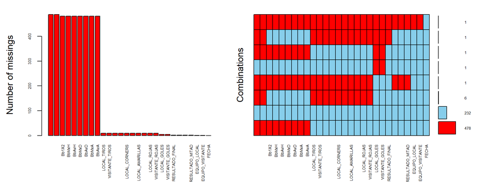

Al realizar la validación de campos vacios, como ilustra el anterior gráfico, 478 de los registros se concentran en 9 variables [*Bb1X2, BbAvA, BbAvD, BbAvH, BbMxA, BbMxD, BbMxH, LOCAL_TIROS_LIBRES, VISITANTE_TIROS_LIBRES*] con valores NA, lo cual representa más del 66% del total de los datos. En vista de que se trata de información de menor relevancia para el análisis del proyecto (Estadísticas de juego y cuotas de casas de apuestas) nuestra decisión es prescindir de estas columnas.

Las nuevas dimensiones de la base de datos, con este cambio son 19 columnas y 721 registros.

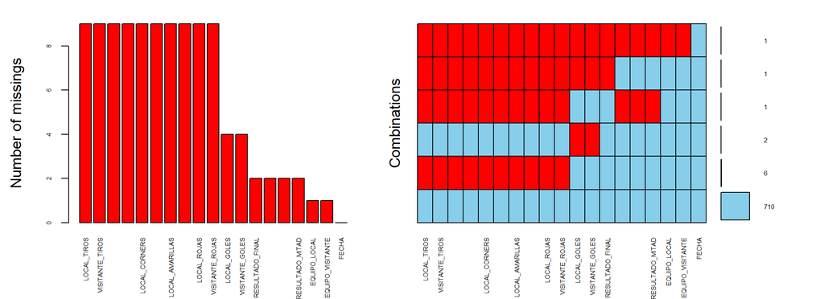

Adicionalmente, al realizar el análisis de las variables restantes con valores nulos [*EQUIPO_LOCAL, EQUIPO_VISITANTE, FECHA, LOCAL_AMARILLAS, LOCAL_CORNERS, LOCAL_GOLES, LOCAL_GOLES_MITAD, LOCAL_ROJAS, LOCAL_TIROS, LOCAL_TIROS_PUERTA, RESULTADO_FINAL, RESULTADO_MITAD, VISITANTE_AMARILLAS, VISITANTE_CORNERS, VISITANTE_GOLES, VISITANTE_GOLES_MITAD, VISITANTE_ROJAS, VISITANTE_TIROS, VISITANTE_TIROS_PUERTA*] encontramos que estas se distribuyen en 11 registros. Uno de los registros sólo dispone información de fecha, con lo cual no representa una obsevación válida para el análisis y procedemos a borrarla. En cuanto a las demás pérdidas, revisamos con el equipo de recolección la posibilidad de imputarlos por medio de *Web Scraping* manual, siendo efectivamente identificada la información en la fuente del siguiente enlace en [transfermarkt.mx](https://www.transfermarkt.mx/).

| FECHA | EQUIPO_LOCAL | EQUIPO_VISITANTE | LOCAL_GOLES | VISITANTE_GOLES | RESULTADO_FINAL | LOCAL_GOLES_MITAD | VISITANTE_GOLES_MITAD | RESULTADO_MITAD | LOCAL_TIROS | VISITANTE_TIROS | LOCAL_TIROS_PUERTA | VISITANTE_TIROS_PUERTA | LOCAL_CORNERS | VISITANTE_CORNERS | LOCAL_AMARILLAS | VISITANTE_AMARILLAS | LOCAL_ROJAS | VISITANTE_ROJAS |
| --- | --- | --- | --- | --- | --- | --- | --- | --- | --- | --- | --- | --- | --- | --- | --- | --- | --- | --- |
| 2018-09-15 | OFI Crete | PAOK | 1 | 3 | Visitante | 1 | 2 | Visitante | NA | NA | NA | NA | NA | NA | NA | NA | NA | NA |
| 2018-09-16 | Atromitos | Lamia | 1 | 0 | Local | 1 | 0 | Local | NA | NA | NA | NA | NA | NA | NA | NA | NA | NA |
| 2018-09-16 | Larisa | Panathinaikos | 1 | 3 | Visitante | 0 | 1 | Visitante | NA | NA | NA | NA | NA | NA | NA | NA | NA | NA |
| 2018-09-16 | Olympiakos | Asteras Tripolis | 2 | 1 | Local | 1 | 0 | Local | NA | NA | NA | NA | NA | NA | NA | NA | NA | NA |
| 2018-09-16 | Xanthi | Panetolikos | 1 | 1 | Empate | 1 | 1 | Empate | NA | NA | NA | NA | NA | NA | NA | NA | NA | NA |
| 2018-09-17 | Aris | Levadeiakos | 2 | 0 | Local | 1 | 0 | Local | NA | NA | NA | NA | NA | NA | NA | NA | NA | NA |
| 2018-10-28 | Panionios | Atromitos | NA | NA | Empate | 1 | 1 | Empate | 9 | 12 | 5 | 5 | 3 | 5 | 6 | 4 | 0 | 0 |
| 2019-03-17 | Panathinaikos | Olympiakos | NA | NA | NA | 0 | 3 | Visitante | NA | NA | NA | NA | NA | NA | NA | NA | NA | NA |
| 2019-08-31 | Panathinaikos | OFI Crete | 1 | 3 | Visitante | NA | NA | NA | NA | NA | NA | NA | NA | NA | NA | NA | NA | NA |
| 2019-12-15 | NA | NA | NA | NA | NA | NA | NA | NA | NA | NA | NA | NA | NA | NA | NA | NA | NA | NA |

[output cut: 1 more lines]

| FECHA | EQUIPO_LOCAL | EQUIPO_VISITANTE | LOCAL_GOLES | VISITANTE_GOLES | RESULTADO_FINAL | LOCAL_GOLES_MITAD | VISITANTE_GOLES_MITAD | RESULTADO_MITAD | LOCAL_TIROS | VISITANTE_TIROS | LOCAL_TIROS_PUERTA | VISITANTE_TIROS_PUERTA | LOCAL_CORNERS | VISITANTE_CORNERS | LOCAL_AMARILLAS | VISITANTE_AMARILLAS | LOCAL_ROJAS | VISITANTE_ROJAS |
| --- | --- | --- | --- | --- | --- | --- | --- | --- | --- | --- | --- | --- | --- | --- | --- | --- | --- | --- |
| 2018-09-15 | OFI Crete | PAOK | 1 | 3 | Visitante | 1 | 2 | Visitante | 4 | 6 | 2 | 4 | 1 | 3 | 4 | 3 | 0 | 0 |
| 2018-09-16 | Atromitos | Lamia | 1 | 0 | Local | 1 | 0 | Local | 8 | 9 | 5 | 5 | 6 | 3 | 1 | 1 | 0 | 1 |
| 2018-09-16 | Larisa | Panathinaikos | 1 | 3 | Visitante | 0 | 1 | Visitante | 6 | 11 | 3 | 8 | 5 | 3 | 5 | 2 | 0 | 0 |
| 2018-09-16 | Olympiakos | Asteras Tripolis | 2 | 1 | Local | 1 | 0 | Local | 13 | 7 | 10 | 4 | 2 | 4 | 2 | 2 | 0 | 0 |
| 2018-09-16 | Xanthi | Panetolikos | 1 | 1 | Empate | 1 | 1 | Empate | 17 | 2 | 7 | 2 | 10 | 0 | 3 | 2 | 0 | 0 |
| 2018-09-17 | Aris | Levadeiakos | 2 | 0 | Local | 1 | 0 | Local | 8 | 11 | 3 | 4 | 4 | 3 | 3 | 4 | 0 | 0 |
| 2018-10-28 | Panionios | Atromitos | 2 | 2 | Empate | 1 | 1 | Empate | 9 | 12 | 5 | 5 | 3 | 5 | 6 | 4 | 0 | 0 |
| 2019-03-17 | Panathinaikos | Olympiakos | 0 | 3 | Visitante | 0 | 3 | Visitante | 6 | 12 | 3 | 5 | 4 | 2 | 0 | 1 | 0 | 0 |
| 2019-08-31 | Panathinaikos | OFI Crete | 1 | 3 | Visitante | 0 | 1 | Visitante | 4 | 10 | 3 | 5 | 1 | 1 | 6 | 3 | 1 | 0 |
| 2020-11-04 | Giannina | Larisa | 1 | 2 | Visitante | 0 | 0 | Empate | 7 | 6 | 3 | 5 | 0 | 5 | 4 | 4 | 1 | 0 |

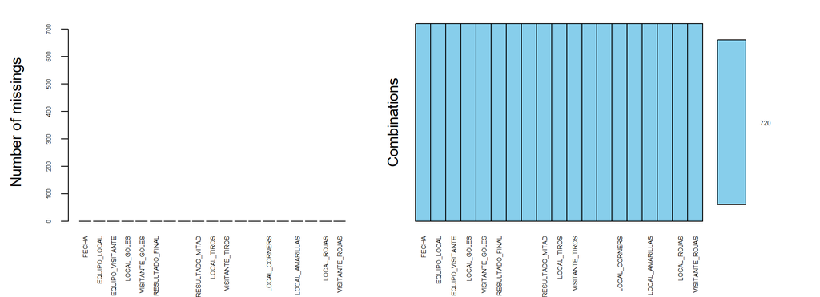

Finalizada la solución de estas anomalías, las nuevas dimensiones de la base de datos son 19 columnas y 720 registros.

## Datos atípicos

Los valores -2 y NA, no tienen sentido dentro del significado de la variable (Cantidad de goles del local al terminar el partido). Aunque 22 y 33 goles no es un valor invalido, si es un valor atipico teniendo en cuenta que la mayor cantidad de goles anotados en la historia en un partido es Australia 31 - 0 Samoa Americana.

|  | Categoría | Freq. Abs. | Freq. Rel. |
| --- | --- | --- | --- |
| 1 | -2 | 1 | 0.001388889 |
| 2 | 0 | 211 | 0.293055556 |
| 3 | 1 | 238 | 0.330555556 |
| 4 | 2 | 158 | 0.219444444 |
| 5 | 3 | 69 | 0.095833333 |
| 6 | 4 | 28 | 0.038888889 |
| 7 | 5 | 12 | 0.016666667 |
| 8 | 7 | 1 | 0.001388889 |
| 9 | 22 | 1 | 0.001388889 |
| 10 | 33 | 1 | 0.001388889 |

[output cut: 1 more lines]

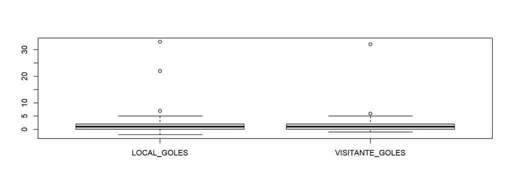

Se procede a identificar los registros invalidos y atipicos en las variables “LOCAL_GOLES” y “VISITANTE_GOLES” para ser corregidos encontrando los resultados de los partidos en la siguiente pagina web: [Resultados](https://el.soccerway.com/matches/2020/06/20/greece/super-league/aek-athens-fc/aris-thessaloniki-fc/3272496/)

| FECHA | EQUIPO_LOCAL | EQUIPO_VISITANTE | LOCAL_GOLES | VISITANTE_GOLES | RESULTADO_FINAL | LOCAL_GOLES_MITAD | VISITANTE_GOLES_MITAD | RESULTADO_MITAD | LOCAL_TIROS | VISITANTE_TIROS | LOCAL_TIROS_PUERTA | VISITANTE_TIROS_PUERTA | LOCAL_CORNERS | VISITANTE_CORNERS | LOCAL_AMARILLAS | VISITANTE_AMARILLAS | LOCAL_ROJAS | VISITANTE_ROJAS |
| --- | --- | --- | --- | --- | --- | --- | --- | --- | --- | --- | --- | --- | --- | --- | --- | --- | --- | --- |
| 2020-06-20 | AEK | Aris | 22 | 32 | Empate | 0 | 0 | Empate | 12 | 6 | 7 | 4 | 4 | 4 | 3 | 2 | 0 | 0 |
| 2021-01-17 | AEK | Atromitos | -2 | -1 | Local | 0 | 0 | Empate | 14 | 6 | 8 | 5 | 4 | 2 | 2 | 5 | 0 | 0 |
| 2021-03-21 | PAOK | AEK | 33 | 1 | Local | 1 | 1 | Empate | 10 | 7 | 5 | 4 | 2 | 9 | 4 | 2 | 0 | 0 |

| FECHA | EQUIPO_LOCAL | EQUIPO_VISITANTE | LOCAL_GOLES | VISITANTE_GOLES | RESULTADO_FINAL | LOCAL_GOLES_MITAD | VISITANTE_GOLES_MITAD | RESULTADO_MITAD | LOCAL_TIROS | VISITANTE_TIROS | LOCAL_TIROS_PUERTA | VISITANTE_TIROS_PUERTA | LOCAL_CORNERS | VISITANTE_CORNERS | LOCAL_AMARILLAS | VISITANTE_AMARILLAS | LOCAL_ROJAS | VISITANTE_ROJAS |
| --- | --- | --- | --- | --- | --- | --- | --- | --- | --- | --- | --- | --- | --- | --- | --- | --- | --- | --- |
| 2020-06-20 | AEK | Aris | 2 | 2 | Empate | 0 | 0 | Empate | 12 | 6 | 7 | 4 | 4 | 4 | 3 | 2 | 0 | 0 |
| 2021-01-17 | AEK | Atromitos | 2 | 1 | Local | 0 | 0 | Empate | 14 | 6 | 8 | 5 | 4 | 2 | 2 | 5 | 0 | 0 |
| 2021-03-21 | PAOK | AEK | 3 | 1 | Local | 1 | 1 | Empate | 10 | 7 | 5 | 4 | 2 | 9 | 4 | 2 | 0 | 0 |

## Errores de digitación

La unica variable que podria presentar errores de digitación seria en los equipos, por lo que se comparan los valores unicos de equipos locales vs visitante.

Tabla. Comparación entre equipos de local y visitante

[output not shown]

La unica anomalia de valores invalidos fue corregida en el punto #4 donde se encontraron valores de goles negativos lo cual no tiene sentido en el contexto.

## Valores inconsistentes

Se trata de buscar valores inconsistentes al comprobar que: 1) El marcador a mitad del tiempo siempre tiene que ser menor al resultado luego de terminar el partido 2) Los goles marcado deben ser congruentes con el resultado del partido. Ejemplo: “Si el partido concluyo 1-1 en goles el resultado_final debe ser empatado”.

| FECHA | EQUIPO_LOCAL | EQUIPO_VISITANTE | LOCAL_GOLES | VISITANTE_GOLES | RESULTADO_FINAL | LOCAL_GOLES_MITAD | VISITANTE_GOLES_MITAD | RESULTADO_MITAD | LOCAL_TIROS | VISITANTE_TIROS | LOCAL_TIROS_PUERTA | VISITANTE_TIROS_PUERTA | LOCAL_CORNERS | VISITANTE_CORNERS | LOCAL_AMARILLAS | VISITANTE_AMARILLAS | LOCAL_ROJAS | VISITANTE_ROJAS |
| --- | --- | --- | --- | --- | --- | --- | --- | --- | --- | --- | --- | --- | --- | --- | --- | --- | --- | --- |

| FECHA | EQUIPO_LOCAL | EQUIPO_VISITANTE | LOCAL_GOLES | VISITANTE_GOLES | RESULTADO_FINAL | LOCAL_GOLES_MITAD | VISITANTE_GOLES_MITAD | RESULTADO_MITAD | LOCAL_TIROS | VISITANTE_TIROS | LOCAL_TIROS_PUERTA | VISITANTE_TIROS_PUERTA | LOCAL_CORNERS | VISITANTE_CORNERS | LOCAL_AMARILLAS | VISITANTE_AMARILLAS | LOCAL_ROJAS | VISITANTE_ROJAS |
| --- | --- | --- | --- | --- | --- | --- | --- | --- | --- | --- | --- | --- | --- | --- | --- | --- | --- | --- |

# Creación de Variables

Variable para saber si se jugo con publico por la pandemia

Se decide crear la variable sintetica “Es_equipo_grande” el cual es un indicador de si un equipo es de renombre. Esta variable se calcula a partir de la cantidad de titulos obtenidos. [Estadisticas](https://es.wikipedia.org/wiki/Superliga_de_Grecia#T%C3%ADtulos_por_club)

[figure not shown]

```
## tibble [720 x 21] (S3: tbl_df/tbl/data.frame)
##  $ FECHA                 : Date[1:720], format: "2018-08-25" "2018-08-25" ...
##  $ EQUIPO_LOCAL          : Factor w/ 17 levels "AEK","Apollon",..: 1 2 13 15 11 14 17 7 4 5 ...
##  $ EQUIPO_VISITANTE      : Factor w/ 17 levels "AEK","Apollon",..: 6 8 5 4 9 10 12 3 1 17 ...
##  $ LOCAL_GOLES           : num [1:720] 2 0 1 1 1 2 0 0 0 0 ...
##  $ VISITANTE_GOLES       : num [1:720] 0 1 2 0 0 2 1 3 1 0 ...
##  $ RESULTADO_FINAL       : Factor w/ 3 levels "Visitante","Empate",..: 3 1 1 3 3 2 1 1 1 2 ...
##  $ LOCAL_GOLES_MITAD     : num [1:720] 1 0 1 0 0 2 0 0 0 0 ...
##  $ VISITANTE_GOLES_MITAD : num [1:720] 0 1 1 0 0 2 0 0 1 0 ...
##  $ RESULTADO_MITAD       : Factor w/ 3 levels "Visitante","Empate",..: 3 1 2 2 2 2 2 2 1 2 ...
##  $ LOCAL_TIROS           : num [1:720] 17 7 6 12 21 15 7 11 4 6 ...
##  $ VISITANTE_TIROS       : num [1:720] 8 5 14 10 4 9 9 11 6 6 ...
##  $ LOCAL_TIROS_PUERTA    : num [1:720] 11 0 4 4 9 9 1 6 1 1 ...
##  $ VISITANTE_TIROS_PUERTA: num [1:720] 2 3 7 4 2 6 4 5 3 2 ...
##  $ LOCAL_CORNERS         : num [1:720] 2 5 4 4 8 9 1 5 1 5 ...
##  $ VISITANTE_CORNERS     : num [1:720] 3 2 4 6 0 3 2 4 7 3 ...
##  $ LOCAL_AMARILLAS       : num [1:720] 2 2 3 2 1 4 2 3 2 2 ...
##  $ VISITANTE_AMARILLAS   : num [1:720] 4 4 4 4 7 2 4 2 4 4 ...
##  $ LOCAL_ROJAS           : num [1:720] 0 0 0 0 0 0 1 0 0 0 ...
##  $ VISITANTE_ROJAS       : num [1:720] 0 0 0 0 0 0 0 0 0 0 ...
##  $ Con_Publico           : chr [1:720] "SI" "SI" "SI" "SI" ...
##  $ Es_equipo_local_grande: chr [1:720] "SI" "NO" "NO" "SI" ...
```

# Conclusiones y recomendaciones

Este informe ha sido dedicado a documentar el trabajo de los equipos de analítica para preparar los datos disponibles que permitan evaluar cómo la situación de pandemia afectó el rendimiento de los equipos de fútbol en sus juegos de local, particularmente en dicho efecto sobre los equipos de la Súperliga de fútbol de Grecia.

Hemos revisado estos aspectos a lo largo de cuatro secciones en donde abordamos detalles respecto a los datos recolectados y a su estructura de variables. Nos referimos además a los hallazgos en materia de anomalías y a las respectivas transformaciones realizadas en consecuencia respecto a: - Eliminar doce registros duplicados que introducian sesgo a futuros procesos analíticos. - Eliminar nueve columnas que no aportaban información suficiente debido a que contenían valores vacíos en más del 66% de los registros. - Imputar información conseguida a través de *web scrapping* manual para completar los registros identificados con datos nulos en variables que pudieron ser recolectadas y agregar valor a futuros procesos analíticos. - No encontramos errores de digitación después de contrastar la información disponible en la base de datos con los datos verificados en fuentes oficiales de la Superliga de Grecia. - Imputar los datos correctos asociados a las anomalías en el caso específico de los casos de goles negativos y por fuera del rango válido de acuerdo con las estadísticas.

También hemos descrito las variables que adicionamos a la base de datos, las cuales consolidan información respecto a si el partido se desarrolló o no durante el período de ausencia de público, e indican el renombre de un equipo a partir de los títulos obtenidos, a fin de para favorecer a los trabajos futuros de este proyecto de analítica.

Algunas recomendaciones de interés para los equipos de recolección de datos consisten en asegurar la extracción de las fuentes de origen usando herramientas que automaticen el levantamiento, con calidad, y reduzcan el esfuerzo de los análisis de exploración de los datos por los demás equipos de analítica.